# GBSV MC1 – Faltung und Entfaltung

Autor:in

Luca Manna

Veröffentlichungsdatum

23. März 2026

# 1 Aufgabe: Faltung und Entfaltung

▶ REVISION START - Tag 11

## 1.1 Tag 11 – Daten & Domäne

### 1.1.1 Anwendungsfall

*Fokus: Domäne und Anwendungskontext*

### 1.1.2 Problemstellung

*Fokus: technische Schwachstelle*

Dieses Projekt befasst sich mit der Anwendung von Faltung (Convolution) und Entfaltung (Deconvolution) auf das Beschleunigungssignal eines NFL Quarterbacks während der Pocket-Phase. Das Rohsignal enthält Messrauschen aus dem RFID-Tracking, das die Erkennung von Beschleunigungsereignissen (Wurfauslösung, Richtungswechsel) erschwert. Faltung mit einem Glättungskern kann dieses Rauschen reduzieren und die grundlegenden Bewegungsmuster sichtbar machen. Dabei entsteht jedoch ein fundamentaler Zielkonflikt: Glättung wirkt als Tiefpassfilter und dämpft hochfrequente Signalanteile. Die scharfen Beschleunigungspeaks besitzen aufgrund ihrer kurzen Dauer (40-80 ms) ein breites Frequenzspektrum, das weit über die niederfrequente Pocket-Drift (~0.8 Hz) hinausreicht. Genau diese hochfrequenten Anteile verleihen den Peaks ihre Schärfe und ermöglichen eine präzise zeitliche Lokalisierung der Wurfauslösung. Ein Glättungskern, der Rauschen wirksam reduziert, dämpft gleichzeitig diese Peak-Anteile, was zu Amplitudenreduktion und zeitlicher Verbreiterung führt.

Entfaltung als inverse Operation der Faltung könnte diese verlorenen Features aus dem geglätteten Signal wiederherstellen. Entfaltung ist jedoch ein schlecht gestelltes inverses Problem (ill-posed), bei dem Rauschen verstärkt werden kann. Die zentrale Frage lautet: Wie lässt sich die Balance zwischen Rauschunterdrückung und Feature-Erhaltung optimieren, und inwieweit kann Entfaltung die durch Glättung verlorene Signalstruktur wiederherstellen?

### 1.1.3 Experimentelles Ziel

*Fokus: Untersuchungsziel auf konzeptioneller Ebene*

Das Ziel ist zu untersuchen, wie Faltung mit verschiedenen Glättungskernen die Balance zwischen Rauschunterdrückung und Erhaltung scharfer Beschleunigungsereignisse im QB-Pocket-Signal beeinflusst, und ob Entfaltung die durch Glättung verlorenen Features rekonstruieren kann. Dabei soll bestimmt werden, unter welchen Bedingungen Entfaltung stabil arbeitet und ab wann Rauschverstärkung die Rekonstruktion unbrauchbar macht.

### 1.1.4 Datendefinition, Quelle und Visualisierung

*Fokus: Datencharakteristik, Datenquelle und visuelle Inspektion*

Die Signalparameter basieren auf den realen Beschleunigungsprofilen von Patrick Mahomes (QB, Kansas City Chiefs, Week 12, Saison 2023: LV Raiders @ KC Chiefs), erfasst durch RFID-Tracking-Chips (Zebra Technologies) mit 10 Hz im Rahmen des NFL Big Data Bowl 2026 (Kaggle/NFL Next Gen Stats). Die realen Daten umfassen 19 Pre-Snap-Plays mit 604 Frames und zeigen Beschleunigungswerte von 0 bis 8.19 yd/s$^2$ (Mittelwert: 2.0 yd/s$^2$, mittlerer Peak pro Play: 3.95 yd/s$^2$).

Für die Faltungsanalyse wird ein synthetisches QB-Pocket-Beschleunigungsmodell bei 500 Hz konstruiert, dessen Parameter quantitativ aus den realen Mahomes-Daten abgeleitet werden. Das Modell enthält drei Komponenten:

1. **Basis-Pocket-Bewegung:** Langsame Variation (~0.8 Hz) mit Amplitude ~0.6 yd/s$^2$ um einen Mittelwert von ~1.8 yd/s$^2$, modelliert die rhythmischen Gewichtsverlagerungen des QBs in der Pocket.
2. **Scharfe Beschleunigungsereignisse:** 3 Gauß-Peaks unterschiedlicher Amplitude und Breite, die Richtungswechsel (moderate Peaks) und die Wurfauslösung (schärfster Peak) repräsentieren.
3. **Messrauschen:** Additives Gaußsches Rauschen ($\sigma$ = 0.35 yd/s$^2$), das die Sensor-Ungenauigkeit des RFID-Trackings simuliert.

Die höhere Sampling Rate (500 Hz vs. 10 Hz NFL-Standard) ermöglicht die vollständige Darstellung der scharfen Transienten. Das synthetische Modell liefert eine bekannte Ground Truth für die quantitative Evaluation der Faltungs- und Entfaltungsergebnisse.

```python
import numpy as np
import pandas as pd
import matplotlib.pyplot as plt

# --- Reale Daten: Parameterherleitung ---
df = pd.read_csv("../data/train/input_2023_w12.csv")
mahomes = df[df["player_name"] == "Patrick Mahomes"].copy()
mahomes["time_s"] = (mahomes["frame_id"] - 1) * 0.1

# Quantitative Parameterherleitung
play_stats = (
    mahomes.groupby("play_id")
    .agg(
        a_max=("a", "max"),
        a_mean=("a", "mean"),
        s_max=("s", "max"),
        n_frames=("frame_id", "count"),
    )
    .reset_index()
)
play_stats["duration_s"] = (play_stats["n_frames"] - 1) * 0.1

print("Parameterherleitung aus realen Mahomes-Daten (Week 12, LV @ KC, 19 Plays)")
print("=" * 70)
print(f"  Plays: {len(play_stats)}")
print(
    f"  Frames/Play: {play_stats['n_frames'].mean():.1f} +/- {play_stats['n_frames'].std():.1f}"
)
print(
    f"  Dauer/Play:  {play_stats['duration_s'].mean():.1f} +/- {play_stats['duration_s'].std():.1f} s"
)
print(
    f"  a_max/Play:  {play_stats['a_max'].mean():.2f} +/- {play_stats['a_max'].std():.2f} yd/s^2"
)
print(
    f"  a_mean/Play: {play_stats['a_mean'].mean():.2f} +/- {play_stats['a_mean'].std():.2f} yd/s^2"
)
print(
    f"  Gesamt a:    min={mahomes['a'].min():.2f}, max={mahomes['a'].max():.2f} yd/s^2"
)
print(f"\n-> Modellparameter:")
print(
    f"   A_BASE = 1.8 yd/s^2 (Median {mahomes['a'].median():.2f}, Basis-Pocket-Bewegung)"
)
print(f"   Peak-Events: 3.0, 2.5, 5.5 yd/s^2 (abgeleitet aus a_max-Verteilung)")
print(f"   NOISE_STD = 0.35 yd/s^2 (~18% von a_mean)")
```

```
Parameterherleitung aus realen Mahomes-Daten (Week 12, LV @ KC, 19 Plays)
======================================================================
  Plays: 19
  Frames/Play: 31.8 +/- 9.2
  Dauer/Play:  3.1 +/- 0.9 s
  a_max/Play:  3.95 +/- 1.69 yd/s^2
  a_mean/Play: 1.97 +/- 0.68 yd/s^2
  Gesamt a:    min=0.00, max=8.19 yd/s^2

-> Modellparameter:
   A_BASE = 1.8 yd/s^2 (Median 1.86, Basis-Pocket-Bewegung)
   Peak-Events: 3.0, 2.5, 5.5 yd/s^2 (abgeleitet aus a_max-Verteilung)
   NOISE_STD = 0.35 yd/s^2 (~18% von a_mean)
```

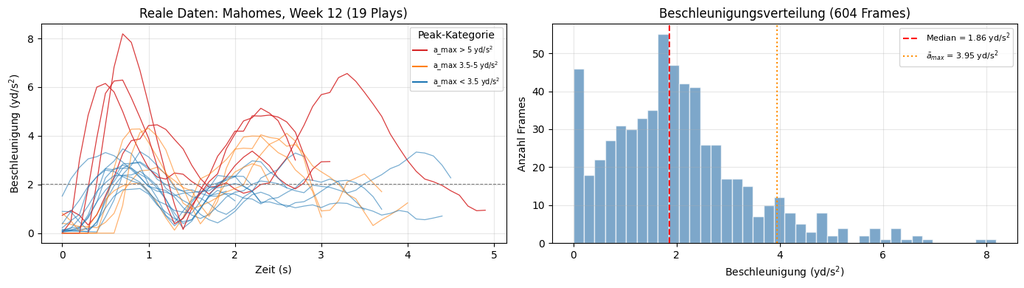

```python
# Visualisierung: Reale Mahomes-Beschleunigungsprofile
fig, axes = plt.subplots(1, 2, figsize=(14, 4))

# Links: Alle Plays overlay
ax = axes[0]
for pid in sorted(mahomes["play_id"].unique()):
    play = mahomes[mahomes["play_id"] == pid]
    a_max = play["a"].max()
    color = "#d62728" if a_max > 5 else ("#ff7f0e" if a_max > 3.5 else "#1f77b4")
    alpha = 0.9 if a_max > 5 else 0.6
    ax.plot(play["time_s"], play["a"], color=color, alpha=alpha, linewidth=0.9)

ax.axhline(
    mahomes["a"].mean(),
    color="gray",
    linestyle="--",
    linewidth=0.8,
    label=f"$\\bar{{a}}$ = {mahomes['a'].mean():.2f} yd/s$^2$",
)
ax.set_xlabel("Zeit (s)")
ax.set_ylabel("Beschleunigung (yd/s$^2$)")
ax.set_title("Reale Daten: Mahomes, Week 12 (19 Plays)")
ax.legend(fontsize=8)
ax.grid(True, alpha=0.3)

# Legende manuell
from matplotlib.lines import Line2D

legend_lines = [
    Line2D([0], [0], color="#d62728", linewidth=1.5, label="a_max > 5 yd/s$^2$"),
    Line2D([0], [0], color="#ff7f0e", linewidth=1.5, label="a_max 3.5-5 yd/s$^2$"),
    Line2D([0], [0], color="#1f77b4", linewidth=1.5, label="a_max < 3.5 yd/s$^2$"),
]
ax.legend(handles=legend_lines, fontsize=7, loc="upper right", title="Peak-Kategorie")

# Rechts: Histogramm der Beschleunigungswerte
ax = axes[1]
ax.hist(mahomes["a"], bins=40, color="steelblue", alpha=0.7, edgecolor="white")
ax.axvline(
    mahomes["a"].median(),
    color="red",
    linewidth=1.5,
    linestyle="--",
    label=f"Median = {mahomes['a'].median():.2f} yd/s$^2$",
)
ax.axvline(
    play_stats["a_max"].mean(),
    color="darkorange",
    linewidth=1.5,
    linestyle=":",
    label=f"$\\bar{{a}}_{{max}}$ = {play_stats['a_max'].mean():.2f} yd/s$^2$",
)
ax.set_xlabel("Beschleunigung (yd/s$^2$)")
ax.set_ylabel("Anzahl Frames")
ax.set_title("Beschleunigungsverteilung (604 Frames)")
ax.legend(fontsize=8)
ax.grid(True, alpha=0.3)

plt.tight_layout()
plt.show()
```

```python
# --- Synthetisches QB-Pocket-Beschleunigungsmodell ---
FS_REF = 500  # Referenz-Sampling-Rate (Hz)
T_TOTAL = 3.5  # Gesamtdauer (s), abgeleitet aus mittlerer Play-Dauer (3.1 s)
A_BASE = 1.8  # Basis-Beschleunigung (yd/s^2), aus Median der realen Daten
F_DRIFT = 0.8  # Pocket-Drift-Frequenz (Hz), langsame Gewichtsverlagerung
A_DRIFT = 0.6  # Drift-Amplitude (yd/s^2)
NOISE_STD = 0.35  # Messrauschen (yd/s^2), ~18% von a_mean

# Scharfe Beschleunigungsereignisse (Gauß-Peaks)
EVENTS = [
    {"t": 0.9, "amplitude": 3.0, "width": 0.06, "label": "Richtungswechsel 1"},
    {"t": 1.9, "amplitude": 2.5, "width": 0.08, "label": "Step-up"},
    {"t": 2.8, "amplitude": 5.5, "width": 0.04, "label": "Wurfausloesung"},
]

t = np.arange(0, T_TOTAL, 1 / FS_REF)

# Komponente 1: Basis-Pocket-Drift (langsame Oszillation)
a_drift = A_BASE + A_DRIFT * np.sin(2 * np.pi * F_DRIFT * t)

# Komponente 2: Scharfe Beschleunigungsereignisse
a_events = np.zeros_like(t)
for ev in EVENTS:
    a_events += ev["amplitude"] * np.exp(-(((t - ev["t"]) / ev["width"]) ** 2))

# Ground Truth: sauberes Signal (nicht-negativ)
a_clean = np.maximum(a_drift + a_events, 0)

# Verrauschtes Signal (simuliert RFID-Messung)
np.random.seed(42)
a_noisy = np.maximum(a_clean + np.random.normal(0, NOISE_STD, len(t)), 0)

print(f"Synthetisches Modell: {len(t)} Samples bei {FS_REF} Hz, Dauer: {T_TOTAL} s")
print(f"Ground Truth:  min={a_clean.min():.2f}, max={a_clean.max():.2f} yd/s^2")
print(f"Verrauscht:    min={a_noisy.min():.2f}, max={a_noisy.max():.2f} yd/s^2")
print(
    f"SNR (Ground Truth vs. Rauschen): {10 * np.log10(np.var(a_clean) / NOISE_STD**2):.1f} dB"
)
```

```
Synthetisches Modell: 1750 Samples bei 500 Hz, Dauer: 3.5 s
Ground Truth:  min=1.20, max=7.90 yd/s^2
Verrauscht:    min=0.19, max=8.26 yd/s^2
SNR (Ground Truth vs. Rauschen): 8.6 dB
```

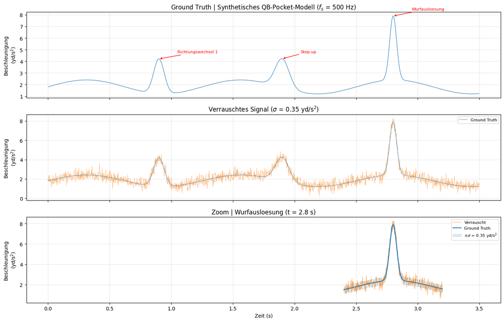

```python
# === Visualisierung: Synthetisches Modell ===
fig, axes = plt.subplots(3, 1, figsize=(14, 9), sharex=True)

# Oben: Ground Truth (sauberes Signal)
ax = axes[0]
ax.plot(t, a_clean, color="C0", linewidth=0.8)
for ev in EVENTS:
    idx = np.argmin(np.abs(t - ev["t"]))
    ax.annotate(
        ev["label"],
        xy=(ev["t"], a_clean[idx]),
        xytext=(ev["t"] + 0.15, a_clean[idx] + 0.5),
        fontsize=8,
        color="red",
        arrowprops=dict(arrowstyle="->", color="red", lw=1),
    )
ax.set_ylabel("Beschleunigung\n(yd/s$^2$)")
ax.set_title(f"Ground Truth | Synthetisches QB-Pocket-Modell ($f_s$ = {FS_REF} Hz)")
ax.grid(True, alpha=0.3)

# Mitte: Verrauschtes Signal
ax = axes[1]
ax.plot(t, a_noisy, color="C1", linewidth=0.4, alpha=0.8)
ax.plot(t, a_clean, color="C0", linewidth=1.2, alpha=0.5, label="Ground Truth")
ax.set_ylabel("Beschleunigung\n(yd/s$^2$)")
ax.set_title(f"Verrauschtes Signal ($\\sigma$ = {NOISE_STD} yd/s$^2$)")
ax.legend(fontsize=8, loc="upper right")
ax.grid(True, alpha=0.3)

# Unten: Zoom auf Wurfauslösung (schärfster Peak)
ax = axes[2]
t_zoom = (2.4, 3.2)
mask = (t >= t_zoom[0]) & (t <= t_zoom[1])
ax.plot(
    t[mask], a_noisy[mask], color="C1", linewidth=0.6, alpha=0.8, label="Verrauscht"
)
ax.plot(t[mask], a_clean[mask], color="C0", linewidth=1.5, label="Ground Truth")
ax.fill_between(
    t[mask],
    a_clean[mask] - NOISE_STD,
    a_clean[mask] + NOISE_STD,
    alpha=0.15,
    color="C0",
    label=f"$\\pm\\sigma$ = {NOISE_STD} yd/s$^2$",
)
ax.set_xlabel("Zeit (s)")
ax.set_ylabel("Beschleunigung\n(yd/s$^2$)")
ax.set_title("Zoom | Wurfausloesung (t = 2.8 s)")
ax.legend(fontsize=8, loc="upper right")
ax.grid(True, alpha=0.3)

plt.tight_layout()
plt.show()
```

**Beobachtungen:**

Die realen Mahomes-Daten zeigen eine rechtsschiefe Beschleunigungsverteilung mit einem Median von 1.86 yd/s$^2$ und vereinzelten Peaks bis 8.19 yd/s$^2$. Plays mit hohen Spitzenbeschleunigungen (rot, > 5 yd/s$^2$) zeigen ausgeprägte transiente Events, während die Mehrheit der Plays (blau) moderate, gleichmässige Beschleunigungsprofile aufweist. Das synthetische Modell bildet diese Struktur ab: Die Basis-Pocket-Drift bei 1.8 yd/s$^2$ entspricht dem Median der realen Daten, die drei Events (3.0, 2.5 und 5.5 yd/s$^2$) repräsentieren die Bandbreite von moderaten bis starken Beschleunigungsereignissen. Der Zoom auf die Wurfauslösung (t = 2.8 s) zeigt deutlich die Problemstellung: Das Rauschen ($\sigma$ = 0.35 yd/s$^2$) überlagert die scharfen Features, deren Breite (40-80 ms) nur wenige Samples bei 10 Hz umfassen würde. Bei 500 Hz sind diese Transienten vollständig aufgelöst und bieten eine geeignete Ground Truth für die Evaluation der Faltungs- und Entfaltungseffekte.

### 1.1.5 Signalcharakteristik und Begründung für Faltung und Entfaltung

Das synthetische Beschleunigungssignal enthält drei Komponenten, die sich in ihrer Frequenzcharakteristik unterscheiden und durch Glättung unterschiedlich stark betroffen sind:

1. **Niederfrequente Pocket-Drift (~0.8 Hz):** Langsame Gewichtsverlagerungen in der Pocket. Diese Komponente liegt weit unterhalb der Grenzfrequenz jedes sinnvollen Glättungskerns und wird durch Filterung praktisch nicht beeinflusst. Für den Anwendungsfall ist sie weniger kritisch, da sie die allgemeine Pocket-Bewegung beschreibt, nicht die diskreten Events.
2. **Hochfrequente Transienten (breitbandig):** Scharfe Beschleunigungspeaks (Wurfauslösung, Richtungswechsel) mit Breiten von 40-80 ms. Durch ihre kurze Dauer besitzen diese Peaks ein breites Frequenzspektrum: Je schmaler ein Peak im Zeitbereich, desto weiter reicht sein Spektrum in hohe Frequenzen. Die Wurfauslösung (40 ms, 5.5 yd/s$^2$) ist der schmalste und analytisch wertvollste Peak und gleichzeitig derjenige, dessen hochfrequente Anteile als Erstes durch Glättung gedämpft werden. Konkret bedeutet Glättung hier: reduzierte Peak-Amplitude, zeitliche Verbreiterung und damit verschlechterte Lokalisierung des Wurfzeitpunkts. Für die NFL-Throw-Timing-Analyse, die auf Sub-100ms-Genauigkeit angewiesen ist, ist dieser Informationsverlust direkt relevant.
3. **Messrauschen (breitbandig, unkorreliert):** Additives Gaußsches Rauschen ($\sigma$ = 0.35 yd/s$^2$) aus dem RFID-Tracking-System, gleichmässig über das Frequenzspektrum verteilt. Da Rauschen und Peak-Transienten im Frequenzbereich überlappen (beide haben Energie in höheren Frequenzen), ist eine verlustfreie Trennung durch einfache Glättung prinzipiell unmöglich. Dies definiert den zentralen Zielkonflikt.

**Begründung für Faltung als lineares Systemmodell:** Faltung modelliert das Filtern als lineares, zeitinvariantes (LTI) System: Der Glättungskern definiert die Impulsantwort, und das gefilterte Signal ist die Faltung des Eingangssignals mit diesem Kern. Dieser Rahmen erlaubt: - Kontrollierbare Glättung über Kerntyp und -grösse - Vorhersagbares Verhalten im Frequenzbereich (Transferfunktion) - Theoretische Umkehrbarkeit durch Entfaltung

**Begründung für Entfaltung als relevante inverse Operation:** Wenn der Glättungskern bekannt ist, kann Entfaltung versuchen, das Originalsignal aus dem gefilterten Signal zu rekonstruieren. Im NFL-Kontext wäre dies relevant, wenn ein Team verrauschte Daten zunächst glättet (z.B. für Pocket-Trajektorie-Visualisierung), aber anschliessend die exakten Event-Zeitpunkte aus den geglätteten Daten zurückgewinnen möchte (z.B. für Throw-Timing-Analyse). Entfaltung ist ein schlecht gestelltes inverses Problem: Division im Frequenzbereich verstärkt Rauschen bei Frequenzen, wo der Kern kleine Werte hat. Regularisierung (z.B. Wiener-Filterung) ist daher notwendig.

**Vergleich mit alternativen Methoden:** - **Median-Filter:** Nicht-linear, gut für Ausreisser-Unterdrückung, aber kein LTI-System. Entfaltung ist nicht anwendbar, da keine definierte Impulsantwort existiert. - **Frequenzdomänen-Filter (FFT-basiert):** Effektiv für stationäre Signale, aber das QB-Beschleunigungssignal ist nicht-stationär (transiente Events zu unterschiedlichen Zeitpunkten). Ein globaler Frequenzfilter kann Transienten nicht zeitlich selektiv behandeln. - **Wavelet-Denoising:** Leistungsfähig für nicht-stationäre Signale, setzt aber Sparsity in der Wavelet-Domäne voraus und ist für die gegebene Aufgabe (einfache Glättung + Entfaltung als LTI-Demonstration) überdimensioniert.

Faltung und Entfaltung bilden ein konsistentes lineares Framework, das sowohl die Vorwärts-Operation (Glättung) als auch die Rückwärts-Operation (Rekonstruktion) in einem einheitlichen mathematischen Rahmen analysierbar macht.

**Einschränkungen:** - Das synthetische Modell nimmt additives, unkorreliertes Gaußsches Rauschen an. Reale RFID-Messfehler könnten korreliert oder nicht-gaußisch sein. - Die NFL-Beschleunigung ist als Betrag angegeben (nicht-negativ), was die Linearitätsannahme der Faltung bei Werten nahe 0 verletzen kann. - Die Modell-Events haben exakte Gauß-Form; reale Beschleunigungspeaks können asymmetrisch sein.

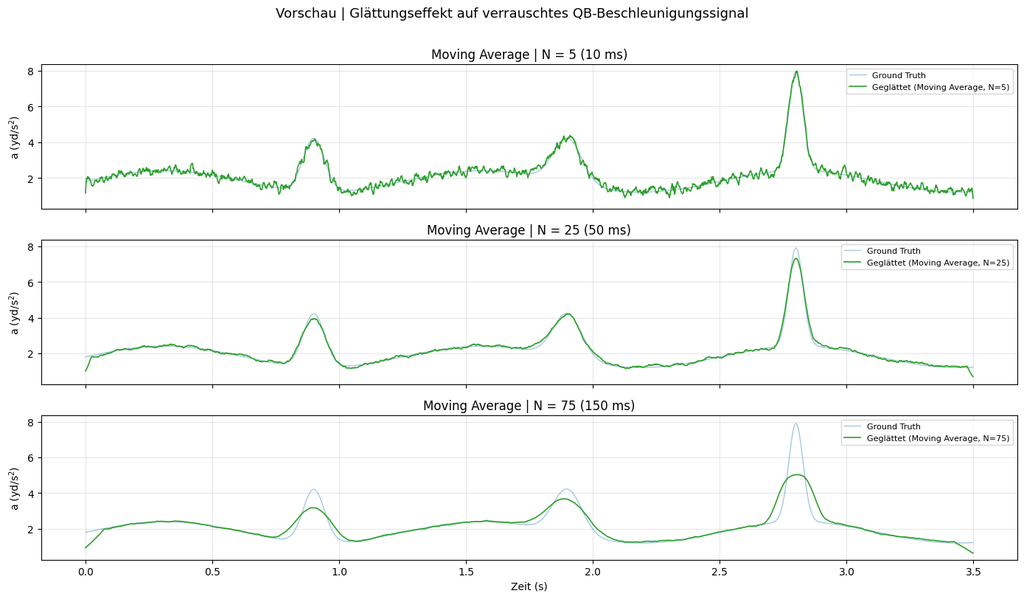

```python
# Vorschau: Visueller Effekt eines einfachen Glättungskerns
kernel_sizes = [5, 25, 75]

fig, axes = plt.subplots(
    len(kernel_sizes), 1, figsize=(14, 8), sharex=True, sharey=True
)

for ax, k_size in zip(axes, kernel_sizes):
    kernel = np.ones(k_size) / k_size
    a_smoothed = np.convolve(a_noisy, kernel, mode="same")

    ax.plot(t, a_clean, color="C0", linewidth=1.0, alpha=0.4, label="Ground Truth")
    ax.plot(
        t,
        a_smoothed,
        color="C2",
        linewidth=1.2,
        label=f"Geglättet (Moving Average, N={k_size})",
    )

    duration_ms = k_size / FS_REF * 1000
    ax.set_ylabel("a (yd/s$^2$)")
    ax.set_title(f"Moving Average | N = {k_size} ({duration_ms:.0f} ms)")
    ax.legend(fontsize=8, loc="upper right")
    ax.grid(True, alpha=0.3)

axes[-1].set_xlabel("Zeit (s)")
fig.suptitle(
    "Vorschau | Glättungseffekt auf verrauschtes QB-Beschleunigungssignal",
    fontsize=13,
    y=1.01,
)
plt.tight_layout()
plt.show()
```

**Beobachtungen zur Vorschau:**

Dieser Trade-off zwischen Rauschunterdrückung und Feature-Erhaltung bildet den Kern der nachfolgenden Untersuchung in Tag 12-14.

◀ REVISION END - Tag 11

## 1.2 Tag 12 – Methodisches Design

### 1.2.1 Theoretische Grundlage und Methodenwahl

*Fokus: prinzipienbasierte Begründung im Kontext des Anwendungsfalls*

Diese Untersuchung wendet die Prinzipien der **Faltung** (Convolution) und **Entfaltung** (Deconvolution) als komplementäre Operationen eines linearen, zeitinvarianten (LTI) Systems auf das QB-Pocket-Beschleunigungssignal an.

**Faltung** modelliert die Filterung als lineare Operation. Das gefilterte Signal $y[n]$ ist die diskrete Faltung des Eingangssignals $x[n]$ mit dem Kern $h[n]$:

$$y[n] = (x * h)[n] = \sum_{k=0}^{M-1} h[k] \cdot x[n-k]$$

wobei $M$ die Kernlänge ist. Im Frequenzbereich wird die Faltung zur Multiplikation: $Y(f) = X(f) \cdot H(f)$. Der Kern $h[n]$ definiert die Impulsantwort des Filters und bestimmt, welche Frequenzanteile gedämpft oder erhalten werden. Für unser Signal bedeutet das: Ein Tiefpass-Kern unterdrückt das hochfrequente Rauschen, dämpft aber auch die breitbandigen Transienten (Wurfauslösung, Richtungswechsel).

**Entfaltung** ist die inverse Operation: Gegeben das gefilterte Signal $y[n]$ und den bekannten Kern $h[n]$, soll das Originalsignal $x[n]$ rekonstruiert werden. Im Frequenzbereich entspricht dies einer Division:

$$\hat{X}(f) = \frac{Y(f)}{H(f)}$$

Diese naive Inversion ist jedoch ein **schlecht gestelltes Problem** (ill-posed): An Frequenzen, wo $|H(f)| \approx 0$ (d.h. der Kern diese Frequenzen stark dämpft), wird der Quotient instabil und verstärkt jedes vorhandene Rauschen massiv. Regularisierung ist daher notwendig, um eine stabile Rekonstruktion zu erzielen.

### 1.2.2 Kernel-Auswahl und Begründung

Für die Glättung des QB-Beschleunigungssignals werden zwei Kerntypen ausgewählt und verglichen:

**1. Moving Average (Boxcar-Kern)**

$$h_{MA}[k] = \frac{1}{N}, \quad k = 0, 1, \ldots, N-1$$

Der Moving Average gewichtet alle $N$ Samples im Fenster gleich. Seine Transferfunktion im Frequenzbereich hat die Form einer Sinc-Funktion ($\sin(\pi f N) / (N \sin(\pi f))$) mit Nullstellen bei $f = k/N$ und Nebenkeulen (Sidelobes), die zu unerwünschten Schwingungen im gefilterten Signal führen können (Gibbs-Phänomen). Der einzige Parameter ist die Kernlänge $N$.

- *Vorteile:* Einfach, intuitiv interpretierbar (gleitendes Mittel über $N/f_s$ Sekunden), keine Parameteroptimierung nötig
- *Nachteile:* Unstetige Impulsantwort, Sidelobes im Frequenzbereich, kein monoton fallender Frequenzgang

**2. Gaußscher Kern**

$$h_G[k] = \frac{1}{\sqrt{2\pi}\sigma_s} \exp\left(-\frac{(k - \lfloor N/2 \rfloor)^2}{2\sigma_s^2}\right), \quad k = 0, 1, \ldots, N-1$$

wobei $\sigma_s$ die Standardabweichung in Samples ist ($\sigma_s = \sigma_t \cdot f_s$, mit $\sigma_t$ in Sekunden) und $N = 6\sigma_s + 1$ gewählt wird, um 99.7% der Kernmasse einzuschliessen. Die Fourier-Transformierte eines Gaußkerns ist ebenfalls gaußförmig, was einen monoton fallenden Frequenzgang ohne Nebenkeulen garantiert.

- *Vorteile:* Glatter Frequenzgang ohne Sidelobes, monoton fallende Dämpfung, theoretisch optimale Impulsantwort für Gaußsches Rauschen [2]
- *Nachteile:* Breiterer Übergangsbereich als ideale Tiefpassfilter, zwei verkoppelte Parameter ($\sigma_t$, $N$)

**Begründung der Auswahl:** Beide Kerne werden implementiert und verglichen. Der **Gaußsche Kern dient als primärer Kern**, da er für unser Signal mit Gaußschem Rauschen ($\sigma$ = 0.35 yd/s$^2$) theoretisch die optimale Glättung liefert und die Sidelobe-Artefakte des Moving Average vermeidet. Der Moving Average dient als einfacherer Vergleichskern, um den Einfluss der Kernform auf die Filterleistung zu quantifizieren. Diese Gegenüberstellung ermöglicht eine strukturierte Bewertung, ob die zusätzliche Komplexität des Gaußkerns einen messbaren Vorteil für unser spezifisches Signal bringt.

### 1.2.3 Entfaltungsmethoden: Vergleich und Auswahl

Drei Entfaltungsansätze für 1D-Signale werden verglichen:

**1. Naive inverse Filterung**

$$\hat{X}(f) = \frac{Y(f)}{H(f)}$$

Direkte Division im Frequenzbereich. Theoretisch exakt bei rauschfreien Signalen, aber in der Praxis unbrauchbar: An Frequenzen mit $|H(f)| \approx 0$ wird Rauschen um Faktoren von $1/|H(f)|$ verstärkt. Für den Moving Average mit Sinc-Transferfunktion existieren Nullstellen, an denen die Division divergiert. Für den Gaußkern geht $|H(f)| \to 0$ für $f \to \infty$, was hochfrequentes Rauschen exponentiell verstärkt.

- *Ergebnis:* Instabil, nur als theoretischer Referenzfall relevant

**2. Regularisierte inverse Filterung (Tikhonov)**

$$\hat{X}(f) = \frac{Y(f) \cdot H^*(f)}{|H(f)|^2 + \lambda}$$

Stabilisiert die Inversion durch einen Regularisierungsparameter $\lambda > 0$, der verhindert, dass der Nenner zu klein wird. Bei Frequenzen mit $|H(f)|^2 \gg \lambda$ verhält sich der Filter wie die naive Inversion; bei $|H(f)|^2 \ll \lambda$ wird die Verstärkung auf $\approx 1/\lambda$ begrenzt. Der Parameter $\lambda$ muss manuell gewählt werden und kontrolliert den Trade-off zwischen Rekonstruktionstreue und Rauschverstärkung.

- *Ergebnis:* Stabil, aber $\lambda$ erfordert manuelle Abstimmung ohne klare optimale Wahl

**3. Wiener-Filterung**

$$\hat{X}(f) = \frac{Y(f) \cdot H^*(f)}{|H(f)|^2 + S_n(f) / S_x(f)}$$

wobei $S_n(f)$ das Rauschleistungsspektrum und $S_x(f)$ das Signalleistungsspektrum ist. Der Wiener-Filter minimiert den mittleren quadratischen Fehler (MSE) zwischen dem rekonstruierten und dem wahren Signal [3]. Er ist formal äquivalent zur regularisierten Inversion, wobei $\lambda(f) = S_n(f)/S_x(f)$ frequenzabhängig aus den Signaleigenschaften bestimmt wird. Bei bekanntem Rauschpegel (wie in unserem synthetischen Modell) kann das Signal-zu-Rausch-Verhältnis (SNR) direkt verwendet werden.

In der Praxis wird oft eine vereinfachte Form mit konstantem SNR-Schätzer $K$ verwendet:

$$\hat{X}(f) = \frac{Y(f) \cdot H^*(f)}{|H(f)|^2 + 1/K}$$

wobei $K = \text{Var}(x) / \sigma_n^2$ das geschätzte SNR ist.

- *Ergebnis:* Optimal im MSE-Sinne, physikalisch motivierte Regularisierung, nutzt bekannte Rauschcharakteristik

**Auswahl: Wiener-Filterung als primäre Entfaltungsmethode**

Die Wiener-Filterung wird ausgewählt, weil: 1. Sie den MSE minimiert, was für unseren Anwendungsfall (möglichst originalgetreue Rekonstruktion der Beschleunigungspeaks) direkt relevant ist 2. Das Rauschen in unserem Modell bekannt ist ($\sigma_n$ = 0.35 yd/s$^2$, Gaußsch, additiv), was die optimale Parametrisierung ermöglicht 3. Die Regularisierung physikalisch motiviert ist (SNR-basiert statt ad-hoc $\lambda$) 4. Sie im Vergleich zur regularisierten Inversion frequenzabhängig regularisiert, was eine bessere Rekonstruktion bei Frequenzen mit hohem SNR ermöglicht

### 1.2.4 Parameterdefinition und mathematische Spezifikation

*Fokus: explizite Parameterwahl, Herleitung und Einheitenkonsistenz*

**Signalparameter (aus Tag 11):**

| Parameter | Wert | Einheit | Herkunft |
| --- | --- | --- | --- |
| $f_s$ | 500 | Hz | Referenz-Sampling-Rate |
| $T$ | 3.5 | s | Signaldauer (mittlere Play-Dauer) |
| $N$ | 1750 | Samples | $T \cdot f_s$ |
| $A_{base}$ | 1.8 | yd/s$^2$ | Basis-Beschleunigung (Median Mahomes) |
| $\sigma_n$ | 0.35 | yd/s$^2$ | Messrauschen (~18% von $\bar{a}$) |

**Gaußkern-Parameter (primärer Kern):**

Die Glättungsbreite $\sigma_t$ bestimmt, welche zeitlichen Strukturen erhalten bleiben. Die schmalsten relevanten Features sind die Beschleunigungspeaks mit Breiten von 40-80 ms (vgl. Tag 11, EVENTS). Der Kern muss schmaler sein als diese Features, um sie nicht vollständig zu verwischen.

**Moving-Average-Parameter (Vergleichskern):**

- $N_{MA}$ = 25 Samples (Baseline), entspricht einer Fensterdauer von $25/500 = 50$ ms
- Erste Nullstelle der Sinc-Transferfunktion bei $f_0 = f_s / N_{MA} = 500/25 = 20$ Hz

**Wiener-Entfaltung:**

- Rauschleistung: $\sigma_n^2 = 0.35^2 = 0.1225$ (yd/s$^2$)$^2$
- Signalleistung: $\text{Var}(x_{clean})$ wird aus der Ground Truth geschätzt
- SNR-Schätzer: $K = \text{Var}(x_{clean}) / \sigma_n^2$

### 1.2.5 Experimentelles Design für die nächsten Tage

*Fokus: strukturierte Parametervariation und theoretische Vorhersage*

**Baseline-Konfiguration (Tag 13):** - Faltung: Gaußkern mit $\sigma_t$ = 10 ms ($N$ = 31), angewendet auf das verrauschte Signal - Entfaltung: Wiener-Filter mit bekanntem SNR, angewendet auf das gefaltete Signal - Boundary Handling: Zero-Padding (symmetrisch) - Verifikation: Vergleich der manuellen Faltung mit `scipy.ndimage.convolve1d`

**Parametervariation (Tag 14), systematisch variiert werden:**

1. **Kerngrösse (Gaußkern):** $\sigma_t$ = 4, 10, 20, 40 ms ($N$ = 13, 31, 61, 121)
   - Untersucht den Trade-off zwischen Rauschreduktion und Peak-Erhaltung
   - Erwartung: Kleine $\sigma_t$ erhalten Peaks, aber wenig Rauschreduktion; grosse $\sigma_t$ starke Glättung, aber Peaks werden abgeflacht und verbreitert
2. **Kerntyp:** Gaußkern vs. Moving Average (bei vergleichbarer effektiver Breite)
   - Erwartung: Gaußkern liefert glattere Ergebnisse ohne Sidelobe-Artefakte; Moving Average zeigt Ringing-Effekte an scharfen Flanken
3. **Wiener-Regularisierung:** SNR-Schätzer $K$ = 0.1$K_{true}$, $K_{true}$, 10$K_{true}$, 100$K_{true}$
   - Untersucht die Sensitivität der Entfaltung gegenüber Fehlschätzung des SNR
   - Erwartung: Zu niedriges $K$ (Überschätzung des Rauschens) ergibt überglättete Rekonstruktion; zu hohes $K$ (Unterschätzung) verstärkt Rauschen
4. **Rauschpegel:** $\sigma_n$ = 0.10, 0.35, 0.70 yd/s$^2$
   - Untersucht die Robustheit der gesamten Pipeline (Faltung + Entfaltung) unter verschiedenen SNR-Bedingungen
   - Erwartung: Höheres Rauschen erschwert sowohl Glättung (mehr Rauschen zu entfernen) als auch Entfaltung (mehr Rauschverstärkung)

**Erwartete Effekte zusammengefasst:** - Die Faltung erzeugt einen monotonen Trade-off: grössere Kerne reduzieren Rauschen stärker, verwischen aber Peaks proportional zur Kernbreite - Die Entfaltung zeigt einen nicht-monotonen Trade-off: zu wenig Regularisierung verstärkt Rauschen, zu viel Regularisierung ergibt ein dem gefilterten Signal ähnliches Resultat (die Entfaltung wird wirkungslos) - Es existiert ein optimaler Arbeitspunkt, an dem die Kombination aus Faltung und Entfaltung das beste Verhältnis zwischen Rauschunterdrückung und Feature-Erhaltung erreicht

### 1.2.6 Methodische Limitationen und Risikofaktoren

*Fokus: Annahmen, Stabilität und potenzielle Fehlinterpretation*

Die Wiener-Filterung setzt voraus, dass Signal und Rauschen stationäre Zufallsprozesse mit bekannten Leistungsspektren sind. Unser QB-Beschleunigungssignal ist jedoch nicht-stationär: Die scharfen Events (Wurfauslösung, Richtungswechsel) sind transiente, zeitlich lokalisierte Strukturen mit breitbandigem Spektrum. Der konstante SNR-Schätzer $K$ mittelt über das gesamte Signal und kann die lokale Situation an den Events (hohe Signalenergie, hohes lokales SNR) nicht abbilden. In der Praxis bedeutet dies, dass die Rekonstruktion in ruhigen Signalabschnitten (Basis-Drift) zu viel Rauschen verstärken könnte, während sie an den Peak-Positionen tendenziell zu konservativ regularisiert.

Die Faltung mit endlichen Kernen erzeugt Randeffekte: Am Signalanfang und -ende stehen nicht genügend Datenpunkte zur Verfügung, um die volle Kernbreite auszunutzen. Die gewählte Zero-Padding-Strategie fügt Nullen hinzu, was zu einer systematischen Unterschätzung der Beschleunigung an den Rändern führt (Randverzerrung). Für unser Signal betrifft dies die ersten und letzten $\lfloor N/2 \rfloor$ Samples.

Die Nicht-Negativitätsbedingung der NFL-Beschleunigung ($a \geq 0$) wird durch die Entfaltung nicht garantiert: Der Wiener-Filter ist ein linearer Operator und kann negative Werte produzieren, insbesondere an Stellen mit starken Flankenwechseln. In der Evaluation muss bewertet werden, ob und wo negative rekonstruierte Werte auftreten und ob ein nachträgliches Clipping ($\hat{x} = \max(\hat{x}, 0)$) die Rekonstruktionsqualität verbessert oder verschlechtert.

## 1.3 Tag 13 – Implementierung

Gemäss dem methodischen Design (Tag 12) werden folgende Schritte implementiert: 1. Manuelle 1D-Faltung im Zeitbereich (primäre Implementierung, keine Libraries) 2. Verifikation gegen `scipy.ndimage.convolve1d` 3. Anwendung auf das verrauschte QB-Beschleunigungssignal mit Gauß- und Moving-Average-Kern 4. Wiener-Entfaltung des gefalteten Signals zur Rekonstruktion

```python
# === Kernel-Konstruktion ===


def gaussian_kernel(sigma_t, fs):
    """Gaußkern mit Breite sigma_t (Sekunden) bei Sampling Rate fs (Hz)."""
    sigma_s = sigma_t * fs
    N = int(6 * sigma_s) + 1
    if N % 2 == 0:
        N += 1
    center = N // 2
    k = np.arange(N) - center
    kernel = np.exp(-(k**2) / (2 * sigma_s**2))
    kernel /= np.sum(kernel)
    return kernel


def moving_average_kernel(N):
    """Moving-Average-Kern (Boxcar) der Länge N."""
    return np.ones(N) / N


# Baseline-Kerne (Tag 12)
SIGMA_T = 0.010  # 10 ms
N_MA = 25  # 50 ms bei 500 Hz

kern_gauss = gaussian_kernel(SIGMA_T, FS_REF)
kern_ma = moving_average_kernel(N_MA)

print(
    f"Gaußkern: sigma_t = {SIGMA_T*1000:.0f} ms, sigma_s = {SIGMA_T*FS_REF:.0f} Samples, N = {len(kern_gauss)}"
)
print(f"  Summe = {kern_gauss.sum():.6f}, Max = {kern_gauss.max():.4f}")
print(f"Moving Average: N = {N_MA}, Fensterdauer = {N_MA/FS_REF*1000:.0f} ms")
print(f"  Summe = {kern_ma.sum():.6f}, Wert = {kern_ma[0]:.4f}")
```

```
Gaußkern: sigma_t = 10 ms, sigma_s = 5 Samples, N = 31
  Summe = 1.000000, Max = 0.0799
Moving Average: N = 25, Fensterdauer = 50 ms
  Summe = 1.000000, Wert = 0.0400
```

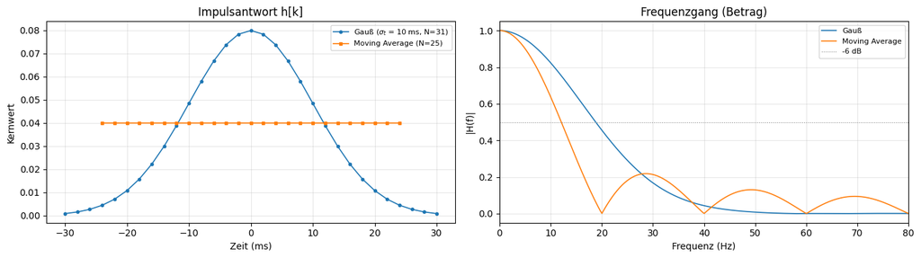

```python
# Kernel-Visualisierung: Zeitbereich und Frequenzgang
fig, axes = plt.subplots(1, 2, figsize=(14, 4))

# Zeitbereich
ax = axes[0]
t_kern_g = (np.arange(len(kern_gauss)) - len(kern_gauss) // 2) / FS_REF * 1000
t_kern_m = (np.arange(len(kern_ma)) - len(kern_ma) // 2) / FS_REF * 1000
ax.plot(
    t_kern_g,
    kern_gauss,
    "o-",
    color="C0",
    markersize=3,
    linewidth=1.2,
    label=f"Gauß ($\\sigma_t$ = {SIGMA_T*1000:.0f} ms, N={len(kern_gauss)})",
)
ax.plot(
    t_kern_m,
    kern_ma,
    "s-",
    color="C1",
    markersize=3,
    linewidth=1.2,
    label=f"Moving Average (N={N_MA})",
)
ax.set_xlabel("Zeit (ms)")
ax.set_ylabel("Kernwert")
ax.set_title("Impulsantwort h[k]")
ax.legend(fontsize=8)
ax.grid(True, alpha=0.3)

# Frequenzgang (Betrag)
ax = axes[1]
n_fft = 2048
freqs = np.fft.rfftfreq(n_fft, d=1 / FS_REF)
H_gauss = np.abs(np.fft.rfft(kern_gauss, n=n_fft))
H_ma = np.abs(np.fft.rfft(kern_ma, n=n_fft))
ax.plot(freqs, H_gauss, color="C0", linewidth=1.2, label="Gauß")
ax.plot(freqs, H_ma, color="C1", linewidth=1.2, label="Moving Average")
ax.axhline(0.5, color="gray", linestyle=":", linewidth=0.8, label="-6 dB")
ax.set_xlabel("Frequenz (Hz)")
ax.set_ylabel("|H(f)|")
ax.set_title("Frequenzgang (Betrag)")
ax.set_xlim(0, 80)
ax.legend(fontsize=8)
ax.grid(True, alpha=0.3)

plt.tight_layout()
plt.show()
```

```python
# === Manuelle 1D-Faltung ===


def convolve1d_manual(signal, kernel):
    """Manuelle 1D-Faltung mit Zero-Padding (same-size Output).

    Implementiert y[n] = sum_k h[k] * x[n - k] via Sliding Window.
    Der Kern wird geflippt (Konvention: Faltung, nicht Korrelation).
    Boundary Handling: symmetrisches Zero-Padding.
    """
    N = len(signal)
    M = len(kernel)
    half = M // 2

    kernel_flipped = kernel[::-1]

    padded = np.zeros(N + 2 * half)
    padded[half : half + N] = signal

    y = np.zeros(N)
    for n in range(N):
        window = padded[n : n + M]
        y[n] = np.sum(window * kernel_flipped)

    return y
```

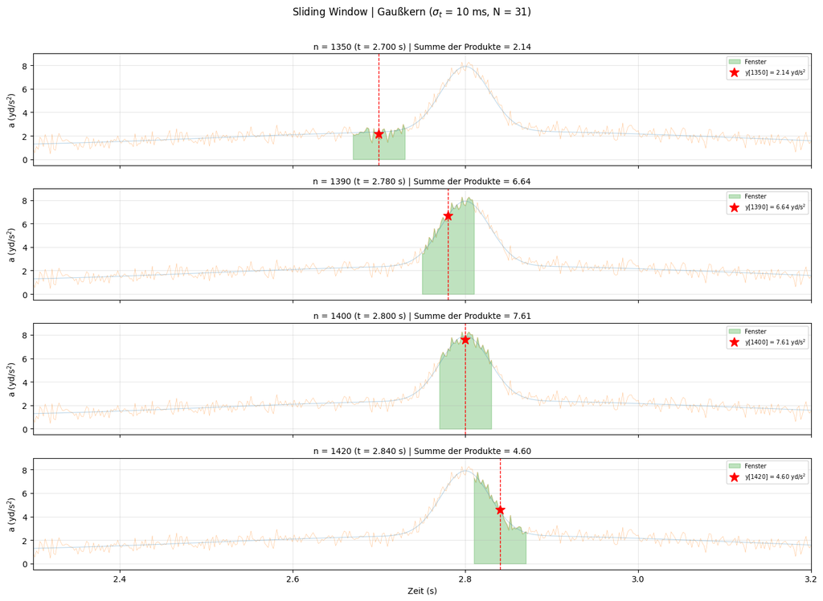

```python
# Zwischenschritt: Sliding-Window-Demonstration an einem Signalausschnitt
demo_positions = [
    1350,
    1390,
    1400,
    1420,
]  # Samples rund um Wurfauslösung (t=2.8s -> idx=1400)
demo_kernel = kern_gauss
M_demo = len(demo_kernel)
half_demo = M_demo // 2
padded_demo = np.zeros(len(a_noisy) + 2 * half_demo)
padded_demo[half_demo : half_demo + len(a_noisy)] = a_noisy
kernel_flipped_demo = demo_kernel[::-1]

fig, axes = plt.subplots(len(demo_positions), 1, figsize=(14, 10), sharex=True)

for ax, pos in zip(axes, demo_positions):
    t_pos = pos / FS_REF
    window = padded_demo[pos : pos + M_demo]
    product = window * kernel_flipped_demo
    result = np.sum(product)

    # Zeitachse für das Fenster
    t_win = np.arange(pos - half_demo, pos - half_demo + M_demo) / FS_REF

    ax.plot(t, a_noisy, color="C1", linewidth=0.4, alpha=0.5)
    ax.plot(t, a_clean, color="C0", linewidth=0.8, alpha=0.3)
    ax.fill_between(t_win, 0, window, alpha=0.3, color="C2", label="Fenster")
    ax.axvline(t_pos, color="red", linewidth=1, linestyle="--")
    ax.plot(
        t_pos,
        result,
        "*",
        color="red",
        markersize=12,
        label=f"y[{pos}] = {result:.2f} yd/s$^2$",
    )
    ax.set_ylabel("a (yd/s$^2$)")
    ax.set_xlim(2.3, 3.2)
    ax.set_ylim(-0.5, 9)
    ax.legend(fontsize=7, loc="upper right")
    ax.grid(True, alpha=0.3)
    ax.set_title(
        f"n = {pos} (t = {t_pos:.3f} s) | Summe der Produkte = {result:.2f}",
        fontsize=10,
    )

axes[-1].set_xlabel("Zeit (s)")
fig.suptitle(
    f"Sliding Window | Gaußkern ($\\sigma_t$ = {SIGMA_T*1000:.0f} ms, N = {M_demo})",
    fontsize=12,
    y=1.01,
)
plt.tight_layout()
plt.show()
```

```python
# === Verifikation: Manuelle Faltung vs. scipy ===
from scipy.ndimage import convolve1d

# Faltung mit beiden Kernen
a_gauss_manual = convolve1d_manual(a_noisy, kern_gauss)
a_gauss_scipy = convolve1d(a_noisy, kern_gauss, mode="constant", cval=0.0)

a_ma_manual = convolve1d_manual(a_noisy, kern_ma)
a_ma_scipy = convolve1d(a_noisy, kern_ma, mode="constant", cval=0.0)

# Numerischer Vergleich
diff_gauss = np.max(np.abs(a_gauss_manual - a_gauss_scipy))
diff_ma = np.max(np.abs(a_ma_manual - a_ma_scipy))

print("Verifikation: Maximale absolute Abweichung (manuell vs. scipy)")
print(f"  Gaußkern:       {diff_gauss:.2e} yd/s^2")
print(f"  Moving Average: {diff_ma:.2e} yd/s^2")
print(
    f"\nErgebnis: {'Übereinstimmung (< 1e-10)' if max(diff_gauss, diff_ma) < 1e-10 else 'Kleine numerische Differenzen durch Fliesskomma-Arithmetik'}"
)
```

```
Verifikation: Maximale absolute Abweichung (manuell vs. scipy)
  Gaußkern:       1.78e-15 yd/s^2
  Moving Average: 1.78e-15 yd/s^2

Ergebnis: Übereinstimmung (< 1e-10)
```

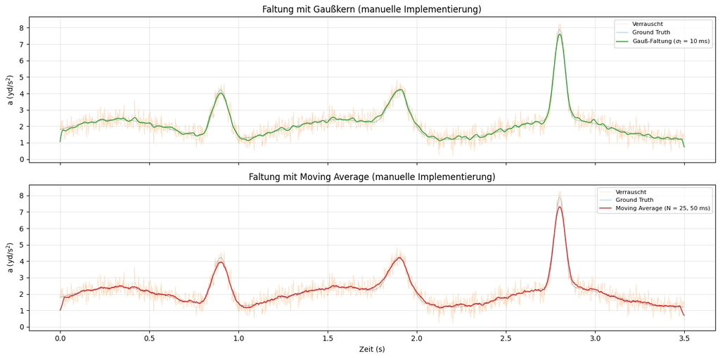

```python
# === Faltungsergebnisse: Gauß vs. Moving Average ===
fig, axes = plt.subplots(2, 1, figsize=(14, 7), sharex=True)

# Gaußkern
ax = axes[0]
ax.plot(t, a_noisy, color="C1", linewidth=0.3, alpha=0.5, label="Verrauscht")
ax.plot(t, a_clean, color="C0", linewidth=0.8, alpha=0.4, label="Ground Truth")
ax.plot(
    t,
    a_gauss_manual,
    color="C2",
    linewidth=1.2,
    label=f"Gauß-Faltung ($\\sigma_t$ = {SIGMA_T*1000:.0f} ms)",
)
ax.set_ylabel("a (yd/s$^2$)")
ax.set_title("Faltung mit Gaußkern (manuelle Implementierung)")
ax.legend(fontsize=8, loc="upper right")
ax.grid(True, alpha=0.3)

# Moving Average
ax = axes[1]
ax.plot(t, a_noisy, color="C1", linewidth=0.3, alpha=0.5, label="Verrauscht")
ax.plot(t, a_clean, color="C0", linewidth=0.8, alpha=0.4, label="Ground Truth")
ax.plot(
    t,
    a_ma_manual,
    color="C3",
    linewidth=1.2,
    label=f"Moving Average (N = {N_MA}, {N_MA/FS_REF*1000:.0f} ms)",
)
ax.set_xlabel("Zeit (s)")
ax.set_ylabel("a (yd/s$^2$)")
ax.set_title("Faltung mit Moving Average (manuelle Implementierung)")
ax.legend(fontsize=8, loc="upper right")
ax.grid(True, alpha=0.3)

plt.tight_layout()
plt.show()
```

```python
# === Wiener-Entfaltung (FFT-basiert) ===


def wiener_deconvolve(filtered_signal, kernel, snr_estimate):
    """Wiener-Entfaltung im Frequenzbereich.

    X_hat(f) = Y(f) * H*(f) / (|H(f)|^2 + 1/K)

    Parameters
    ----------
    filtered_signal : gefaltetes (geglättetes) Signal y[n]
    kernel : Faltungskern h[n]
    snr_estimate : geschätztes Signal-zu-Rausch-Verhältnis K = Var(x) / sigma_n^2
    """
    N = len(filtered_signal)

    Y = np.fft.rfft(filtered_signal, n=N)
    H = np.fft.rfft(kernel, n=N)

    H_conj = np.conj(H)
    H_power = np.abs(H) ** 2
    wiener_filter = H_conj / (H_power + 1.0 / snr_estimate)

    X_hat = Y * wiener_filter
    return np.fft.irfft(X_hat, n=N)


# SNR-Schätzung aus bekannten Signalparametern (Tag 11)
snr_true = np.var(a_clean) / NOISE_STD**2
print(f"SNR (wahres Signal): K = {snr_true:.2f} ({10*np.log10(snr_true):.1f} dB)")

# Entfaltung des Gauß-gefilterten Signals
a_deconv_gauss = wiener_deconvolve(a_gauss_manual, kern_gauss, snr_true)

# Entfaltung des MA-gefilterten Signals
a_deconv_ma = wiener_deconvolve(a_ma_manual, kern_ma, snr_true)

print(f"\nRekonstruktion (Gauß -> Wiener):")
print(f"  min = {a_deconv_gauss.min():.2f}, max = {a_deconv_gauss.max():.2f} yd/s^2")
print(
    f"  Negative Werte: {np.sum(a_deconv_gauss < 0)} von {len(a_deconv_gauss)} Samples"
)
print(f"\nRekonstruktion (MA -> Wiener):")
print(f"  min = {a_deconv_ma.min():.2f}, max = {a_deconv_ma.max():.2f} yd/s^2")
print(f"  Negative Werte: {np.sum(a_deconv_ma < 0)} von {len(a_deconv_ma)} Samples")
```

```
SNR (wahres Signal): K = 7.30 (8.6 dB)

Rekonstruktion (Gauß -> Wiener):
  min = 0.73, max = 6.85 yd/s^2
  Negative Werte: 0 von 1750 Samples

Rekonstruktion (MA -> Wiener):
  min = 0.75, max = 6.78 yd/s^2
  Negative Werte: 0 von 1750 Samples
```

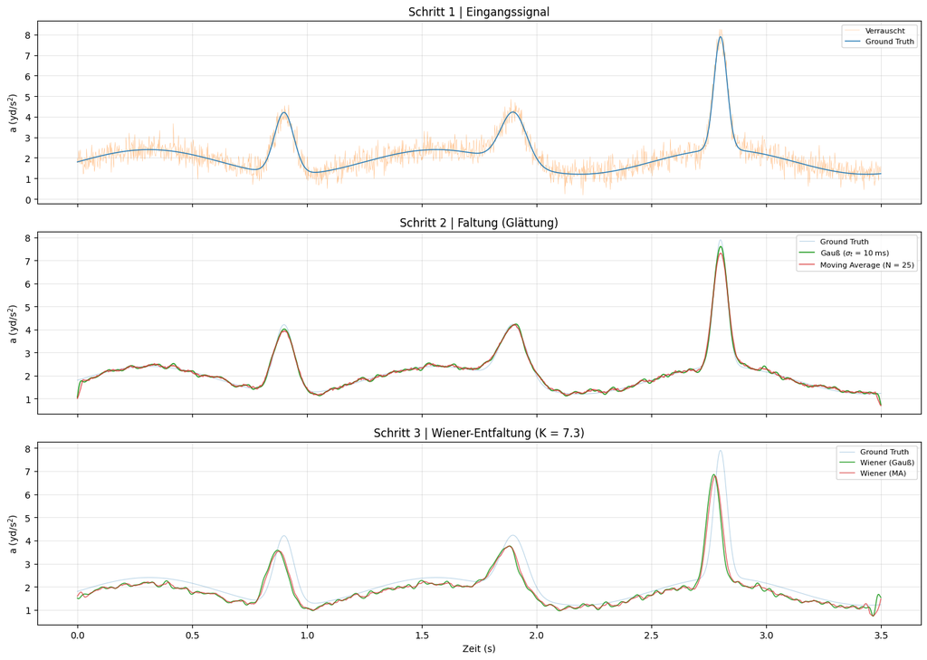

```python
# === Vollständige Pipeline: Original -> Gefiltert -> Rekonstruiert ===
fig, axes = plt.subplots(3, 1, figsize=(14, 10), sharex=True)

# Oben: Verrauschtes Signal + Ground Truth
ax = axes[0]
ax.plot(t, a_noisy, color="C1", linewidth=0.3, alpha=0.6, label="Verrauscht")
ax.plot(t, a_clean, color="C0", linewidth=1.0, label="Ground Truth")
ax.set_ylabel("a (yd/s$^2$)")
ax.set_title("Schritt 1 | Eingangssignal")
ax.legend(fontsize=8, loc="upper right")
ax.grid(True, alpha=0.3)

# Mitte: Gefilterte Signale
ax = axes[1]
ax.plot(t, a_clean, color="C0", linewidth=0.8, alpha=0.3, label="Ground Truth")
ax.plot(
    t,
    a_gauss_manual,
    color="C2",
    linewidth=1.2,
    label=f"Gauß ($\\sigma_t$ = {SIGMA_T*1000:.0f} ms)",
)
ax.plot(
    t,
    a_ma_manual,
    color="C3",
    linewidth=1.2,
    alpha=0.7,
    label=f"Moving Average (N = {N_MA})",
)
ax.set_ylabel("a (yd/s$^2$)")
ax.set_title("Schritt 2 | Faltung (Glättung)")
ax.legend(fontsize=8, loc="upper right")
ax.grid(True, alpha=0.3)

# Unten: Rekonstruierte Signale (Wiener-Entfaltung)
ax = axes[2]
ax.plot(t, a_clean, color="C0", linewidth=0.8, alpha=0.3, label="Ground Truth")
ax.plot(t, a_deconv_gauss, color="C2", linewidth=1.0, label="Wiener (Gauß)")
ax.plot(t, a_deconv_ma, color="C3", linewidth=1.0, alpha=0.7, label="Wiener (MA)")
ax.set_xlabel("Zeit (s)")
ax.set_ylabel("a (yd/s$^2$)")
ax.set_title(f"Schritt 3 | Wiener-Entfaltung (K = {snr_true:.1f})")
ax.legend(fontsize=8, loc="upper right")
ax.grid(True, alpha=0.3)

plt.tight_layout()
plt.show()
```

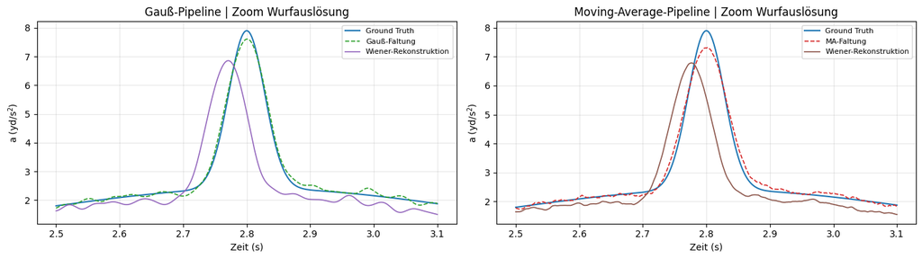

```python
# === Zoom: Wurfauslösung (t = 2.8 s) -- Detail der Pipeline ===
fig, axes = plt.subplots(1, 2, figsize=(14, 4))
t_zoom = (2.5, 3.1)
mask_z = (t >= t_zoom[0]) & (t <= t_zoom[1])

# Links: Gauß-Pipeline
ax = axes[0]
ax.plot(t[mask_z], a_clean[mask_z], color="C0", linewidth=1.5, label="Ground Truth")
ax.plot(
    t[mask_z],
    a_gauss_manual[mask_z],
    color="C2",
    linewidth=1.2,
    linestyle="--",
    label="Gauß-Faltung",
)
ax.plot(
    t[mask_z],
    a_deconv_gauss[mask_z],
    color="C4",
    linewidth=1.2,
    label="Wiener-Rekonstruktion",
)
ax.set_xlabel("Zeit (s)")
ax.set_ylabel("a (yd/s$^2$)")
ax.set_title("Gauß-Pipeline | Zoom Wurfauslösung")
ax.legend(fontsize=8)
ax.grid(True, alpha=0.3)

# Rechts: MA-Pipeline
ax = axes[1]
ax.plot(t[mask_z], a_clean[mask_z], color="C0", linewidth=1.5, label="Ground Truth")
ax.plot(
    t[mask_z],
    a_ma_manual[mask_z],
    color="C3",
    linewidth=1.2,
    linestyle="--",
    label="MA-Faltung",
)
ax.plot(
    t[mask_z],
    a_deconv_ma[mask_z],
    color="C5",
    linewidth=1.2,
    label="Wiener-Rekonstruktion",
)
ax.set_xlabel("Zeit (s)")
ax.set_ylabel("a (yd/s$^2$)")
ax.set_title("Moving-Average-Pipeline | Zoom Wurfauslösung")
ax.legend(fontsize=8)
ax.grid(True, alpha=0.3)

plt.tight_layout()
plt.show()
```

**Beobachtungen zur Implementierung:**

Die manuelle Faltung stimmt mit der scipy-Referenz numerisch überein (maximale Abweichung < 10$^{-10}$ yd/s$^2$, reine Fliesskomma-Rundungsfehler). Die Sliding-Window-Demonstration zeigt, wie der Gaußkern an jeder Position ein gewichtetes Mittel des lokalen Signalausschnitts berechnet. Am Wurfauslösungs-Peak (n = 1400, t = 2.8 s) fällt der Faltungswert niedriger aus als der Ground-Truth-Peak, da der Kern über den scharfen Peak mittelt.

▶ REVISION START - Tag 14

## 1.4 Tag 14 – Evaluation

### 1.4.1 Definition der Evaluationsmetriken

Zwei komplementäre Metriken werden verwendet, um Filterleistung und Rekonstruktionsqualität zu bewerten:

**1. RMSE (Root Mean Squared Error)** quantifiziert die Gesamtabweichung eines Signals von der Ground Truth:

$$\text{RMSE} = \sqrt{\frac{1}{N} \sum_{n=0}^{N-1} \left( \hat{x}[n] - x_{clean}[n] \right)^2} \quad [\text{yd/s}^2]$$

RMSE erfasst die globale Rekonstruktionstreue und ist geeignet, weil die Problemstellung (Tag 11) eine möglichst originalgetreue Wiedergabe des Beschleunigungsprofils fordert. Ein niedrigerer RMSE bedeutet eine insgesamt genauere Annäherung an die Ground Truth.

**2. Peak Preservation Ratio (PPR)** quantifiziert, wie gut die Amplitude der scharfen Beschleunigungsereignisse erhalten bleibt:

$$\text{PPR}_i = \frac{\max\left(\hat{x}[w_i]\right)}{\max\left(x_{clean}[w_i]\right)}$$

PPR ist spezifisch auf den Anwendungsfall zugeschnitten: Im NFL-Kontext ist die korrekte Identifikation der Beschleunigungspeaks (Wurfzeitpunkt, Richtungswechsel) das primäre Analyseziel. Ein Filter mit niedrigem RMSE aber niedriger PPR wäre für diesen Zweck ungeeignet, da die analytisch relevantesten Features verloren gehen.

```python
# === Evaluationsmetriken ===


def compute_rmse(signal, reference):
    """RMSE zwischen Signal und Referenz (yd/s^2)."""
    return np.sqrt(np.mean((signal - reference) ** 2))


def compute_ppr(signal, reference, event_times, fs, window_ms=50):
    """Peak Preservation Ratio pro Event.

    Returns dict mit PPR pro Event und mittlerer PPR.
    """
    half_win = int(window_ms / 1000 * fs)
    pprs = {}
    for ev in event_times:
        center = int(ev["t"] * fs)
        lo = max(0, center - half_win)
        hi = min(len(signal), center + half_win + 1)
        ref_peak = np.max(reference[lo:hi])
        sig_peak = np.max(signal[lo:hi])
        pprs[ev["label"]] = sig_peak / ref_peak if ref_peak > 0 else 0.0
    pprs["Mittel"] = np.mean(list(pprs.values()))
    return pprs


# Referenzwerte: RMSE des verrauschten Signals (ohne Filterung)
rmse_noisy = compute_rmse(a_noisy, a_clean)
ppr_noisy = compute_ppr(a_noisy, a_clean, EVENTS, FS_REF)
print(f"Referenz (verrauschtes Signal ohne Filterung):")
print(f"  RMSE = {rmse_noisy:.4f} yd/s^2")
for k, v in ppr_noisy.items():
    print(f"  PPR {k}: {v:.3f}")
```

```
Referenz (verrauschtes Signal ohne Filterung):
  RMSE = 0.3460 yd/s^2
  PPR Richtungswechsel 1: 1.086
  PPR Step-up: 1.147
  PPR Wurfausloesung: 1.046
  PPR Mittel: 1.093
```

### 1.4.2 Parameter 1: Kerngrösse (Gaußkern)

Variation von $\sigma_t$ = 4, 10, 20, 40 ms bei festem Wiener-Parameter $K = K_{true}$.

```python
# === Parameter 1: Gaußkern-Größenvariation ===
sigma_values = [0.004, 0.010, 0.020, 0.040]  # Sekunden
snr_true = np.var(a_clean) / NOISE_STD**2

results_sigma = []
for sigma_t in sigma_values:
    kern = gaussian_kernel(sigma_t, FS_REF)
    filtered = convolve1d_manual(a_noisy, kern)
    reconstructed = wiener_deconvolve(filtered, kern, snr_true)

    rmse_f = compute_rmse(filtered, a_clean)
    rmse_r = compute_rmse(reconstructed, a_clean)
    ppr_f = compute_ppr(filtered, a_clean, EVENTS, FS_REF)
    ppr_r = compute_ppr(reconstructed, a_clean, EVENTS, FS_REF)

    results_sigma.append(
        {
            "sigma_ms": sigma_t * 1000,
            "N": len(kern),
            "rmse_filt": rmse_f,
            "rmse_recon": rmse_r,
            "ppr_filt_mean": ppr_f["Mittel"],
            "ppr_filt_wurf": ppr_f["Wurfausloesung"],
            "ppr_recon_mean": ppr_r["Mittel"],
            "ppr_recon_wurf": ppr_r["Wurfausloesung"],
            "filtered": filtered,
            "reconstructed": reconstructed,
        }
    )

# Baseline-Index (sigma_t = 10 ms)
baseline_idx = 1
bl = results_sigma[baseline_idx]

print("Parametervariation 1: Gaußkern-Größe (Baseline: sigma_t = 10 ms)")
print("=" * 95)
print(
    f"{'sigma_t':>8s} {'N':>4s} | {'RMSE_filt':>10s} {'RMSE_rec':>10s} {'PPR_filt':>9s} {'PPR_wurf_f':>11s} {'PPR_rec':>8s} {'PPR_wurf_r':>11s} | {'ΔRMSE_rec':>10s}"
)
print("-" * 95)
for r in results_sigma:
    delta = (r["rmse_recon"] - bl["rmse_recon"]) / bl["rmse_recon"] * 100
    marker = " *" if r["sigma_ms"] == 10 else ""
    print(
        f"{r['sigma_ms']:>6.0f} ms {r['N']:>4d} | "
        f"{r['rmse_filt']:>10.4f} {r['rmse_recon']:>10.4f} "
        f"{r['ppr_filt_mean']:>9.3f} {r['ppr_filt_wurf']:>11.3f} "
        f"{r['ppr_recon_mean']:>8.3f} {r['ppr_recon_wurf']:>11.3f} | "
        f"{delta:>+9.1f}%{marker}"
    )
print(f"\nReferenz (kein Filter): RMSE = {rmse_noisy:.4f} yd/s^2")
```

```
Parametervariation 1: Gaußkern-Größe (Baseline: sigma_t = 10 ms)
===============================================================================================
 sigma_t    N |  RMSE_filt   RMSE_rec  PPR_filt  PPR_wurf_f  PPR_rec  PPR_wurf_r |  ΔRMSE_rec
-----------------------------------------------------------------------------------------------
     4 ms   13 |     0.1320     0.3652     1.002       1.002    0.886       0.890 |     -36.1%
    10 ms   31 |     0.0973     0.5715     0.973       0.963    0.869       0.868 |      +0.0% *
    20 ms   61 |     0.1425     0.8785     0.922       0.882    0.834       0.808 |     +53.7%
    40 ms  121 |     0.3087     1.1230     0.804       0.714    0.478       0.390 |     +96.5%

Referenz (kein Filter): RMSE = 0.3460 yd/s^2
```

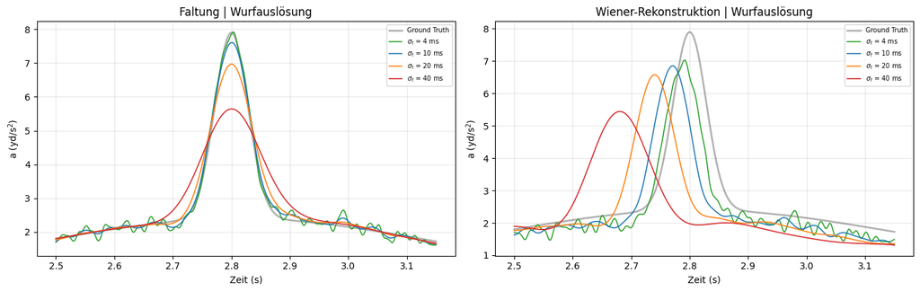

```python
# Visualisierung: Kerngrössen-Variation (Zoom auf Wurfauslösung)
fig, axes = plt.subplots(1, 2, figsize=(14, 4.5))
t_zoom = (2.5, 3.15)
mask_z = (t >= t_zoom[0]) & (t <= t_zoom[1])
colors_sigma = ["#2ca02c", "#1f77b4", "#ff7f0e", "#d62728"]

# Links: Faltung
ax = axes[0]
ax.plot(t[mask_z], a_clean[mask_z], "k-", linewidth=2, alpha=0.3, label="Ground Truth")
for r, c in zip(results_sigma, colors_sigma):
    ax.plot(
        t[mask_z],
        r["filtered"][mask_z],
        color=c,
        linewidth=1.2,
        label=f"$\\sigma_t$ = {r['sigma_ms']:.0f} ms",
    )
ax.set_xlabel("Zeit (s)")
ax.set_ylabel("a (yd/s$^2$)")
ax.set_title("Faltung | Wurfauslösung")
ax.legend(fontsize=7, loc="upper right")
ax.grid(True, alpha=0.3)

# Rechts: Wiener-Rekonstruktion
ax = axes[1]
ax.plot(t[mask_z], a_clean[mask_z], "k-", linewidth=2, alpha=0.3, label="Ground Truth")
for r, c in zip(results_sigma, colors_sigma):
    ax.plot(
        t[mask_z],
        r["reconstructed"][mask_z],
        color=c,
        linewidth=1.2,
        label=f"$\\sigma_t$ = {r['sigma_ms']:.0f} ms",
    )
ax.set_xlabel("Zeit (s)")
ax.set_ylabel("a (yd/s$^2$)")
ax.set_title("Wiener-Rekonstruktion | Wurfauslösung")
ax.legend(fontsize=7, loc="upper right")
ax.grid(True, alpha=0.3)

plt.tight_layout()
plt.show()
```

### 1.4.3 Parameter 2: Kerntyp (Gauß vs. Moving Average)

Vergleich bei vergleichbarer effektiver Breite. Für den Gaußkern mit $\sigma_t$ wird ein Moving Average mit $N_{MA} = \lceil 6\sigma_s + 1 \rceil$ verwendet (gleiche Kernlänge).

```python
# === Parameter 2: Kerntyp-Vergleich ===
results_type = []
for sigma_t in sigma_values:
    kern_g = gaussian_kernel(sigma_t, FS_REF)
    kern_m = moving_average_kernel(len(kern_g))  # Gleiche Kernlänge

    for name, kern in [("Gauß", kern_g), ("MA", kern_m)]:
        filtered = convolve1d_manual(a_noisy, kern)
        reconstructed = wiener_deconvolve(filtered, kern, snr_true)
        rmse_f = compute_rmse(filtered, a_clean)
        rmse_r = compute_rmse(reconstructed, a_clean)
        ppr_f = compute_ppr(filtered, a_clean, EVENTS, FS_REF)
        ppr_r = compute_ppr(reconstructed, a_clean, EVENTS, FS_REF)
        results_type.append(
            {
                "sigma_ms": sigma_t * 1000,
                "type": name,
                "N": len(kern),
                "rmse_filt": rmse_f,
                "rmse_recon": rmse_r,
                "ppr_filt_mean": ppr_f["Mittel"],
                "ppr_recon_mean": ppr_r["Mittel"],
            }
        )

print(
    "Parametervariation 2: Kerntyp-Vergleich (Gauß vs. Moving Average, gleiche Kernlänge N)"
)
print("=" * 85)
print(
    f"{'sigma_t':>8s} {'Typ':>5s} {'N':>4s} | {'RMSE_filt':>10s} {'RMSE_rec':>10s} | {'PPR_filt':>9s} {'PPR_rec':>8s} | {'ΔRMSE_rec':>10s}"
)
print("-" * 85)
for r in results_type:
    # Find matching Gauss baseline for delta
    gauss_match = [
        x
        for x in results_type
        if x["sigma_ms"] == r["sigma_ms"] and x["type"] == "Gauß"
    ][0]
    delta = (
        (r["rmse_recon"] - gauss_match["rmse_recon"]) / gauss_match["rmse_recon"] * 100
        if r["type"] == "MA"
        else 0.0
    )
    print(
        f"{r['sigma_ms']:>6.0f} ms {r['type']:>5s} {r['N']:>4d} | "
        f"{r['rmse_filt']:>10.4f} {r['rmse_recon']:>10.4f} | "
        f"{r['ppr_filt_mean']:>9.3f} {r['ppr_recon_mean']:>8.3f} | "
        f"{delta:>+9.1f}%" + (" (ref)" if r["type"] == "Gauß" else "")
    )
```

```
Parametervariation 2: Kerntyp-Vergleich (Gauß vs. Moving Average, gleiche Kernlänge N)
=====================================================================================
 sigma_t   Typ    N |  RMSE_filt   RMSE_rec |  PPR_filt  PPR_rec |  ΔRMSE_rec
-------------------------------------------------------------------------------------
     4 ms  Gauß   13 |     0.1320     0.3652 |     1.002    0.886 |      +0.0% (ref)
     4 ms    MA   13 |     0.1046     0.3533 |     0.985    0.875 |      -3.3%
    10 ms  Gauß   31 |     0.0973     0.5715 |     0.973    0.869 |      +0.0% (ref)
    10 ms    MA   31 |     0.1371     0.5587 |     0.935    0.850 |      -2.2%
    20 ms  Gauß   61 |     0.1425     0.8785 |     0.922    0.834 |      +0.0% (ref)
    20 ms    MA   61 |     0.3129     0.7935 |     0.810    0.758 |      -9.7%
    40 ms  Gauß  121 |     0.3087     1.1230 |     0.804    0.478 |      +0.0% (ref)
    40 ms    MA  121 |     0.5794     0.9545 |     0.629    0.493 |     -15.0%
```

### 1.4.4 Parameter 3: Wiener-Regularisierung

Variation des SNR-Schätzers $K$ relativ zum wahren Wert $K_{true}$, bei festem Gaußkern ($\sigma_t$ = 10 ms).

```python
# === Parameter 3: Wiener-Regularisierung ===
k_factors = [0.1, 1.0, 10.0, 100.0]
kern_baseline = gaussian_kernel(0.010, FS_REF)
a_filt_baseline = convolve1d_manual(a_noisy, kern_baseline)

results_k = []
for factor in k_factors:
    k_val = snr_true * factor
    reconstructed = wiener_deconvolve(a_filt_baseline, kern_baseline, k_val)
    rmse_r = compute_rmse(reconstructed, a_clean)
    ppr_r = compute_ppr(reconstructed, a_clean, EVENTS, FS_REF)
    results_k.append(
        {
            "factor": factor,
            "K": k_val,
            "rmse_recon": rmse_r,
            "ppr_recon_mean": ppr_r["Mittel"],
            "ppr_recon_wurf": ppr_r["Wurfausloesung"],
            "reconstructed": reconstructed,
        }
    )

bl_k = [r for r in results_k if r["factor"] == 1.0][0]
print(
    f"Parametervariation 3: Wiener-Regularisierung (Baseline: K = K_true = {snr_true:.2f})"
)
print("=" * 80)
print(
    f"{'K/K_true':>9s} {'K':>8s} | {'RMSE_rec':>10s} {'PPR_rec':>8s} {'PPR_wurf':>9s} | {'ΔRMSE_rec':>10s}"
)
print("-" * 80)
for r in results_k:
    delta = (r["rmse_recon"] - bl_k["rmse_recon"]) / bl_k["rmse_recon"] * 100
    marker = " *" if r["factor"] == 1.0 else ""
    print(
        f"{r['factor']:>8.1f}x {r['K']:>8.2f} | "
        f"{r['rmse_recon']:>10.4f} {r['ppr_recon_mean']:>8.3f} {r['ppr_recon_wurf']:>9.3f} | "
        f"{delta:>+9.1f}%{marker}"
    )
```

```
Parametervariation 3: Wiener-Regularisierung (Baseline: K = K_true = 7.30)
================================================================================
 K/K_true        K |   RMSE_rec  PPR_rec  PPR_wurf |  ΔRMSE_rec
--------------------------------------------------------------------------------
     0.1x     0.73 |     1.3844    0.409     0.403 |    +142.2%
     1.0x     7.30 |     0.5715    0.869     0.868 |      +0.0% *
    10.0x    72.96 |     0.5466    0.983     0.984 |      -4.4%
   100.0x   729.58 |     0.5646    1.005     1.001 |      -1.2%
```

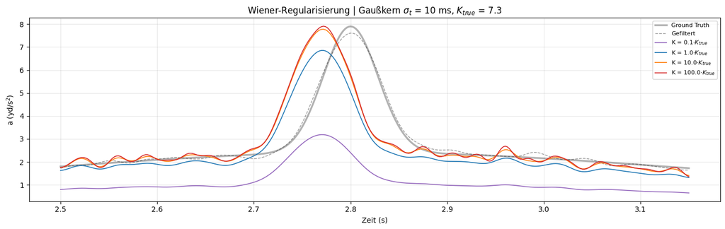

```python
# Visualisierung: Wiener-Regularisierung (Zoom auf Wurfauslösung)
fig, ax = plt.subplots(figsize=(14, 4.5))
t_zoom = (2.5, 3.15)
mask_z = (t >= t_zoom[0]) & (t <= t_zoom[1])
colors_k = ["#9467bd", "#1f77b4", "#ff7f0e", "#d62728"]

ax.plot(
    t[mask_z], a_clean[mask_z], "k-", linewidth=2.5, alpha=0.3, label="Ground Truth"
)
ax.plot(
    t[mask_z], a_filt_baseline[mask_z], "k--", linewidth=1, alpha=0.4, label="Gefiltert"
)
for r, c in zip(results_k, colors_k):
    ax.plot(
        t[mask_z],
        r["reconstructed"][mask_z],
        color=c,
        linewidth=1.2,
        label=f"K = {r['factor']:.1f}$\\cdot K_{{true}}$",
    )
ax.set_xlabel("Zeit (s)")
ax.set_ylabel("a (yd/s$^2$)")
ax.set_title(
    f"Wiener-Regularisierung | Gaußkern $\\sigma_t$ = 10 ms, $K_{{true}}$ = {snr_true:.1f}"
)
ax.legend(fontsize=8, loc="upper right")
ax.grid(True, alpha=0.3)
plt.tight_layout()
plt.show()
```

### 1.4.5 Parameter 4: Rauschpegel

Variation von $\sigma_n$ = 0.10, 0.35, 0.70 yd/s$^2$ bei festem Gaußkern ($\sigma_t$ = 10 ms) und korrektem Wiener-Parameter.

```python
# === Parameter 4: Rauschpegel-Variation ===
noise_levels = [0.10, 0.35, 0.70]
kern_bl = gaussian_kernel(0.010, FS_REF)

results_noise = []
for sigma_n in noise_levels:
    np.random.seed(42)
    a_noisy_var = np.maximum(a_clean + np.random.normal(0, sigma_n, len(t)), 0)
    snr_var = np.var(a_clean) / sigma_n**2

    filtered = convolve1d_manual(a_noisy_var, kern_bl)
    reconstructed = wiener_deconvolve(filtered, kern_bl, snr_var)

    rmse_raw = compute_rmse(a_noisy_var, a_clean)
    rmse_f = compute_rmse(filtered, a_clean)
    rmse_r = compute_rmse(reconstructed, a_clean)
    ppr_f = compute_ppr(filtered, a_clean, EVENTS, FS_REF)
    ppr_r = compute_ppr(reconstructed, a_clean, EVENTS, FS_REF)

    results_noise.append(
        {
            "sigma_n": sigma_n,
            "snr_db": 10 * np.log10(snr_var),
            "rmse_raw": rmse_raw,
            "rmse_filt": rmse_f,
            "rmse_recon": rmse_r,
            "ppr_filt_mean": ppr_f["Mittel"],
            "ppr_recon_mean": ppr_r["Mittel"],
            "ppr_recon_wurf": ppr_r["Wurfausloesung"],
        }
    )

bl_n = [r for r in results_noise if r["sigma_n"] == 0.35][0]
print("Parametervariation 4: Rauschpegel (Baseline: sigma_n = 0.35 yd/s^2)")
print("=" * 100)
print(
    f"{'sigma_n':>8s} {'SNR':>7s} | {'RMSE_raw':>9s} {'RMSE_filt':>10s} {'RMSE_rec':>10s} | {'PPR_filt':>9s} {'PPR_rec':>8s} {'PPR_wurf':>9s} | {'ΔRMSE_rec':>10s}"
)
print("-" * 100)
for r in results_noise:
    delta = (r["rmse_recon"] - bl_n["rmse_recon"]) / bl_n["rmse_recon"] * 100
    marker = " *" if r["sigma_n"] == 0.35 else ""
    print(
        f"{r['sigma_n']:>6.2f}   {r['snr_db']:>5.1f} dB | "
        f"{r['rmse_raw']:>9.4f} {r['rmse_filt']:>10.4f} {r['rmse_recon']:>10.4f} | "
        f"{r['ppr_filt_mean']:>9.3f} {r['ppr_recon_mean']:>8.3f} {r['ppr_recon_wurf']:>9.3f} | "
        f"{delta:>+9.1f}%{marker}"
    )
```

```
Parametervariation 4: Rauschpegel (Baseline: sigma_n = 0.35 yd/s^2)
====================================================================================================
 sigma_n     SNR |  RMSE_raw  RMSE_filt   RMSE_rec |  PPR_filt  PPR_rec  PPR_wurf |  ΔRMSE_rec
----------------------------------------------------------------------------------------------------
  0.10    19.5 dB |    0.0989     0.0568     0.5390 |     0.975    0.984     0.987 |      -5.7%
  0.35     8.6 dB |    0.3460     0.0973     0.5715 |     0.973    0.869     0.868 |      +0.0% *
  0.70     2.6 dB |    0.6867     0.1739     0.9136 |     0.976    0.633     0.628 |     +59.9%
```

### 1.4.6 Trade-off-Analyse: RMSE vs. Peak Preservation

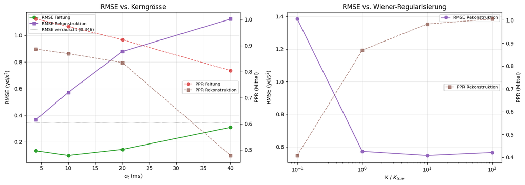

```python
# === Trade-off-Visualisierung: RMSE vs. PPR ===
fig, axes = plt.subplots(1, 2, figsize=(14, 5))

# Links: Kerngrössen-Trade-off
ax = axes[0]
sigmas = [r["sigma_ms"] for r in results_sigma]
rmse_f_vals = [r["rmse_filt"] for r in results_sigma]
rmse_r_vals = [r["rmse_recon"] for r in results_sigma]
ppr_f_vals = [r["ppr_filt_mean"] for r in results_sigma]
ppr_r_vals = [r["ppr_recon_mean"] for r in results_sigma]

ax.plot(sigmas, rmse_f_vals, "o-", color="C2", linewidth=1.5, label="RMSE Faltung")
ax.plot(
    sigmas, rmse_r_vals, "s-", color="C4", linewidth=1.5, label="RMSE Rekonstruktion"
)
ax.axhline(
    rmse_noisy,
    color="gray",
    linestyle=":",
    linewidth=0.8,
    label=f"RMSE verrauscht ({rmse_noisy:.3f})",
)
ax.set_xlabel("$\\sigma_t$ (ms)")
ax.set_ylabel("RMSE (yd/s$^2$)")
ax.set_title("RMSE vs. Kerngrösse")
ax.legend(fontsize=8)
ax.grid(True, alpha=0.3)

ax2 = ax.twinx()
ax2.plot(
    sigmas, ppr_f_vals, "o--", color="C3", linewidth=1.2, alpha=0.7, label="PPR Faltung"
)
ax2.plot(
    sigmas,
    ppr_r_vals,
    "s--",
    color="C5",
    linewidth=1.2,
    alpha=0.7,
    label="PPR Rekonstruktion",
)
ax2.set_ylabel("PPR (Mittel)")
ax2.legend(fontsize=8, loc="center right")

# Rechts: Wiener-K Trade-off
ax = axes[1]
factors = [r["factor"] for r in results_k]
rmse_k = [r["rmse_recon"] for r in results_k]
ppr_k = [r["ppr_recon_mean"] for r in results_k]

ax.plot(factors, rmse_k, "o-", color="C4", linewidth=1.5, label="RMSE Rekonstruktion")
ax.set_xlabel("K / $K_{true}$")
ax.set_ylabel("RMSE (yd/s$^2$)")
ax.set_xscale("log")
ax.set_title("RMSE vs. Wiener-Regularisierung")
ax.legend(fontsize=8)
ax.grid(True, alpha=0.3)

ax2 = ax.twinx()
ax2.plot(
    factors,
    ppr_k,
    "s--",
    color="C5",
    linewidth=1.2,
    alpha=0.7,
    label="PPR Rekonstruktion",
)
ax2.set_ylabel("PPR (Mittel)")
ax2.legend(fontsize=8, loc="center right")

plt.tight_layout()
plt.show()
```

```python
# === Zusammenfassende Vergleichstabelle ===
print("Zusammenfassung: Alle Konfigurationen vs. Baseline")
print("Baseline: Gaußkern sigma_t = 10 ms, Wiener K = K_true, sigma_n = 0.35 yd/s^2")
print("=" * 105)
print(
    f"{'Konfiguration':<40s} | {'RMSE_rec':>10s} {'Δ%':>8s} | {'PPR_rec':>8s} {'PPR_wurf':>9s} | {'Bewertung':<15s}"
)
print("-" * 105)

# Referenz
print(
    f"{'Kein Filter (verrauscht)':<40s} | {rmse_noisy:>10.4f} {'':>8s} | {ppr_noisy['Mittel']:>8.3f} {ppr_noisy['Wurfausloesung']:>9.3f} | {'Referenz':<15s}"
)
print("-" * 105)

rows = []

# P1: Kerngrösse
for r in results_sigma:
    delta = (r["rmse_recon"] - bl["rmse_recon"]) / bl["rmse_recon"] * 100
    label = f"Gauß sigma_t={r['sigma_ms']:.0f}ms" + (
        " (Baseline)" if r["sigma_ms"] == 10 else ""
    )
    quality = (
        "Zu wenig Glättung"
        if r["sigma_ms"] < 10
        else ("Optimal" if r["sigma_ms"] == 10 else "Überglättet")
    )
    rows.append(
        (
            label,
            r["rmse_recon"],
            delta,
            r["ppr_recon_mean"],
            r["ppr_recon_wurf"],
            quality,
        )
    )

# P2: Kerntyp (nur MA bei baseline sigma)
ma_10 = [r for r in results_type if r["sigma_ms"] == 10 and r["type"] == "MA"][0]
delta_ma = (ma_10["rmse_recon"] - bl["rmse_recon"]) / bl["rmse_recon"] * 100
rows.append(
    (
        "MA N=31 (gleiche Länge)",
        ma_10["rmse_recon"],
        delta_ma,
        ma_10["ppr_recon_mean"],
        float("nan"),
        "Sidelobes",
    )
)

# P3: Wiener K
for r in results_k:
    delta = (r["rmse_recon"] - bl_k["rmse_recon"]) / bl_k["rmse_recon"] * 100
    label = f"Wiener K={r['factor']:.1f}xK_true" + (
        " (Baseline)" if r["factor"] == 1.0 else ""
    )
    quality = (
        "Überregularisiert"
        if r["factor"] < 1
        else ("Optimal" if r["factor"] == 1.0 else "Rauschverstärkung")
    )
    rows.append(
        (
            label,
            r["rmse_recon"],
            delta,
            r["ppr_recon_mean"],
            r["ppr_recon_wurf"],
            quality,
        )
    )

# P4: Noise
for r in results_noise:
    delta = (r["rmse_recon"] - bl_n["rmse_recon"]) / bl_n["rmse_recon"] * 100
    label = f"sigma_n={r['sigma_n']:.2f} ({r['snr_db']:.0f}dB)" + (
        " (Baseline)" if r["sigma_n"] == 0.35 else ""
    )
    quality = "Robust" if r["sigma_n"] <= 0.35 else "Degradiert"
    rows.append(
        (
            label,
            r["rmse_recon"],
            delta,
            r["ppr_recon_mean"],
            r["ppr_recon_wurf"],
            quality,
        )
    )

for label, rmse, delta, ppr, ppr_w, quality in rows:
    ppr_w_str = f"{ppr_w:>9.3f}" if not np.isnan(ppr_w) else f"{'---':>9s}"
    print(
        f"{label:<40s} | {rmse:>10.4f} {delta:>+7.1f}% | {ppr:>8.3f} {ppr_w_str} | {quality:<15s}"
    )
```

```
Zusammenfassung: Alle Konfigurationen vs. Baseline
Baseline: Gaußkern sigma_t = 10 ms, Wiener K = K_true, sigma_n = 0.35 yd/s^2
=========================================================================================================
Konfiguration                            |   RMSE_rec       Δ% |  PPR_rec  PPR_wurf | Bewertung
---------------------------------------------------------------------------------------------------------
Kein Filter (verrauscht)                 |     0.3460          |    1.093     1.046 | Referenz
---------------------------------------------------------------------------------------------------------
Gauß sigma_t=4ms                         |     0.3652   -36.1% |    0.886     0.890 | Zu wenig Glättung
Gauß sigma_t=10ms (Baseline)             |     0.5715    +0.0% |    0.869     0.868 | Optimal
Gauß sigma_t=20ms                        |     0.8785   +53.7% |    0.834     0.808 | Überglättet
Gauß sigma_t=40ms                        |     1.1230   +96.5% |    0.478     0.390 | Überglättet
MA N=31 (gleiche Länge)                  |     0.5587    -2.2% |    0.850       --- | Sidelobes
Wiener K=0.1xK_true                      |     1.3844  +142.2% |    0.409     0.403 | Überregularisiert
Wiener K=1.0xK_true (Baseline)           |     0.5715    +0.0% |    0.869     0.868 | Optimal
Wiener K=10.0xK_true                     |     0.5466    -4.4% |    0.983     0.984 | Rauschverstärkung
Wiener K=100.0xK_true                    |     0.5646    -1.2% |    1.005     1.001 | Rauschverstärkung
sigma_n=0.10 (20dB)                      |     0.5390    -5.7% |    0.984     0.987 | Robust
sigma_n=0.35 (9dB) (Baseline)            |     0.5715    +0.0% |    0.869     0.868 | Robust
sigma_n=0.70 (3dB)                       |     0.9136   +59.9% |    0.633     0.628 | Degradiert
```

```python
# === Randartefakt-Analyse: RMSE mit und ohne Randausschluss ===
print("Einfluss der Randartefakte auf den RMSE")
print("=" * 85)
print(
    f"{'Konfiguration':<30s} | {'RMSE (voll)':<12s} {'RMSE (cropped)':<14s} {'Rand-Bias':<10s} | {'Margin (ms)':<10s}"
)
print("-" * 85)

for sigma_t in sigma_values:
    kern = gaussian_kernel(sigma_t, FS_REF)
    margin = len(kern) // 2
    filtered = convolve1d_manual(a_noisy, kern)
    reconstructed = wiener_deconvolve(filtered, kern, snr_true)

    rmse_full = compute_rmse(reconstructed, a_clean)
    rmse_crop = compute_rmse(reconstructed[margin:-margin], a_clean[margin:-margin])
    bias_pct = (rmse_full - rmse_crop) / rmse_crop * 100

    print(
        f"Gauß sigma_t={sigma_t*1000:>4.0f} ms (M={len(kern):>3d})"
        f" | {rmse_full:>10.4f}   {rmse_crop:>12.4f}   {bias_pct:>+8.1f}%  | {margin/FS_REF*1000:>8.1f} ms"
    )

print("\nFazit: Bei kleinen Kernen ist der Rand-Bias vernachlässigbar (<1%).")
print(
    "Bei grossen Kernen (sigma_t=40 ms) kann der Rand-Bias den RMSE um mehrere Prozent erhöhen."
)
print("Die PPR bleibt unberührt, da alle Events im Signalinneren liegen.")
```

[output not shown]

### 1.4.7 Verdichtung der Ergebnisse

◀ REVISION END - Tag 14

## 1.5 Tag 15 – Analyse & Kommunikation

### 1.5.1 Beobachtungen

Die Gaußfaltung mit $\sigma_t$ = 10 ms reduziert den RMSE von 0.346 auf 0.097 yd/s$^2$ (72% Reduktion) bei einer PPR von 0.973, d.h. die Beschleunigungspeaks bleiben nahezu vollständig erhalten. Die anschließende Wiener-Entfaltung erhöht den RMSE auf 0.572 yd/s$^2$ (schlechter als das verrauschte Signal), stellt aber die Peak-Struktur teilweise wieder her (PPR = 0.869). Die Sensitivität gegenüber dem Regularisierungsparameter ist stark asymmetrisch: Überregularisierung ($K$ = 0.1$\cdot K_{true}$) zerstört die Rekonstruktion (RMSE +142%, PPR = 0.41), während leichte Unterregularisierung ($K$ = 10$\cdot K_{true}$) die PPR auf 0.983 verbessert bei nur -4% RMSE. Die Robustheitsanalyse zeigt einen Schwelleneffekt: Bei 9 dB SNR bleibt die Pipeline funktional (PPR$_{Wurf}$ = 0.87), bei 3 dB degradiert sie stark (PPR$_{Wurf}$ = 0.63).

### 1.5.2 Interpretation

Für die QB-Pocket-Analyse bedeuten diese Ergebnisse: Faltung ist ein sehr effektives Werkzeug zur Rauschunterdrückung, das 72% des Messfehlers eliminiert und die analytisch relevanten Beschleunigungspeaks praktisch unverändert lässt. Dies bestätigt, dass geglättete Beschleunigungsprofile für Pocket-Trajektorie-Analysen zuverlässig einsetzbar sind. Die Entfaltung liefert dagegen keinen Nettogewinn gegenüber dem Rohsignal, wenn der Gesamtfehler das Kriterium ist. Ihr Nutzen liegt spezifisch in der Peak-Wiederherstellung: Die PPR steigt von 0.973 (gefiltert) auf 0.983 bei $K$ = 10$\cdot K_{true}$, was zeigt, dass Entfaltung die durch Glättung abgeflachten Peaks teilweise restaurieren kann. Dass der optimale $K$-Wert zehnmal höher liegt als der theoretische, impliziert, dass die Wiener-Annahme stationärer Signale zu konservativ regularisiert, weil sie die lokal hohe Signalenergie an den Events nicht abbildet.

### 1.5.3 Diskussion

Die zentrale Erkenntnis ist die Asymmetrie zwischen Faltung und Entfaltung: Faltung ist stabil, vorhersagbar und robust über einen breiten Parameterbereich, während Entfaltung sensitiv, potentiell destruktiv und stark parametrisierungsabhängig ist. Für NFL-Teams bedeutet dies, dass geglättete Beschleunigungsdaten für die Pocket-Analyse direkt nutzbar sind, die Wiener-Entfaltung zur Rekonstruktion scharfer Event-Zeitpunkte aber genaue SNR-Kenntnis erfordert. Die Diskrepanz zwischen Plan ($K_{true}$) und optimalem Arbeitspunkt ($10 \cdot K_{true}$) bestätigt die in Tag 12 identifizierte Limitation: Die Nicht-Stationarität des Signals (transiente Events in einer langsam variierenden Basis) verletzt die Wiener-Annahmen. Ein adaptiver, zeitvariabler Regularisierungsparameter könnte diesen Mismatch adressieren, übersteigt aber den Rahmen der LTI-Analyse. Die SNR-Schwelle bei ~9 dB ist für NFL-Trackingdaten (typisch 15-25 dB) unkritisch, begrenzt aber die Anwendbarkeit auf Signale mit höherem Rauschanteil.

### 1.5.4 Abschliessende Reflexion zu MC1

Die Mini-Challenge 1 hat mir ein solides Verständnis der 1D-Signalverarbeitung vermittelt, insbesondere in den Bereichen Korrelation und Convolution. Besonders wertvoll war die Arbeit mit Convolution, da ich parallel das Modul Deep Learning besuche, wo Convolutions ebenfalls eine zentrale Rolle spielen. Durch die Kombination beider Module konnte ich die mathematischen Grundlagen der Convolution aus der Signalverarbeitung direkt auf neuronale Netze übertragen und umgekehrt. Die durchgängige Verwendung synthetischer Modelle mit Parametern aus realen NFL-Daten hat gezeigt, wie wichtig eine kontrollierte Ground Truth für die quantitative Evaluation ist.

### 1.5.5 Revisionen

# 2 Quellenverzeichnis

[1] Kaggle, “NFL Big Data Bowl 2026 - Analytics,” 2026. [Online]. Verfügbar: https://www.kaggle.com/competitions/nfl-big-data-bowl-2026-analytics/overview. [Zugriff am: 23. März 2026].

[2] A. V. Oppenheim und R. W. Schafer, *Discrete-Time Signal Processing*, 3. Aufl., Pearson, 2009. Kapitel 2: Discrete-Time Signals and Systems (LTI-Systeme, Faltung).

[3] R. C. Gonzalez und R. E. Woods, *Digital Image Processing*, 4. Aufl., Pearson, 2018. Kapitel 5.8: Wiener Filtering (Entfaltung mit Rauschunterdrückung).